title: ‘Patrones de distribución de las Estelas decoradas de la Península Ibérica’ author: “Javier Gallardo Contreras” date: ‘2023-05-31’ output: pdf_document: default —

#1. INTRODUCCIÓN:

La presencia de las conocidas como estelas decoradas, en todas sus variantes, es un elemento distintivo, e incluso identitario, de la compleja composición del paisaje ibérico, por su iconicidad y por el gran simbolismo que desprenden. Mientras que las intervenciones a pequeña escala en el medio paisajístico definieron a las sociedades preneolíticas y/o no agrarias, el Neolítico (y posteriormente la Edad de los Metales: Calcolítico, Bronce y Hierro) se caracterizó por un cambio en la manera en que el ser humano concebía el paisaje, su organización y su transformación (Carrero-Pazos, 2018). Esto se produjo, entre otras cosas, a través de la construcción de una serie de monumentos que, perpetuándose en el tiempo, vertebraron los territorios de las sociedades vivas. Estas singulares manifestaciones artísticas comprenden una horquilla cronológica que ha podido situarse desde principios del Bronce (ca. 2200-850/825 AC) hasta la Edad del Hierro (ca. 850/825-700 AC) (Díaz-Guardaminos, 2010). Sin embargo, debemos aclarar que el fenómeno de las estelas no es algo nuevo ni exclusivo del suroeste peninsular. Con función y simbología general, estos monumentos llevan existiendo en buena parte de la fachada atlántica europea, como mínimo desde el Neolítico, si bien es cierto que la iconografía y detalles de las estelas peninsulares las hacen únicas de esta región en las cronologías previamente mencionadas. Sin ser nuestra pretensión extendernos en exceso en este tema, sería ilustrativo realizar al menos un acercamiento básico a los dos principales tipos en los que se clasifican las estelas de la Prehistoria peninsular:

Estos singulares monumentos han venido siendo objeto de estudio desde el pasado siglo, pero muy especialmente en las últimas décadas (70-80, en adelante). Sin embargo, y a pesar de ello, las interpretaciones que de estas representaciones simbólico-artísticas se ha dado están aún en desarrollo. Sin negar una posible significación funeraria-conmemorativa (como remarcaron autores como Almagro-Bach en los años 60, haciendo alusión a estas como “estelas-guijarro” o “ídolos-estela”), la creencia de que estos monumentos prehistóricos funcionasen como tumbas fue una primera interpretación que actualmente, aunque continúa vigente, apenas sí tiene cabida en el paradigma “estelar” de la cuestión. Por su parte, la asociación de estelas con caminos, límites de fronteras (geográficas o ecológicas) e hitos visibles, goza de mayor plausibilidad, si bien su significado continúa siendo objeto de una amplia controversia en el panorama epistemológico debido a la posible multifuncionalidad que podrían encerrar. El estudio de las relaciones de las estelas con el espacio que las rodea es crucial para comprender la interrelación que se establece entre ellas y el medio ambiente en que se localizan, es decir, analizar por igual la geografía y la cronología de estos elementos. La aparición de las estelas en lugares significativos de las redes terrestres que comunican las diferentes zonas del Suroeste entre sí y con el exterior puede haber sido su función primordial”, y que las representaciones en ellas grabadas “contengan una información codificada, accesible a quien se mueva por las vías donde fueron situadas” (Galán y Martín, 1993: 17). En este sentido, la existencia de las estelas del suroeste como hitos significativos en los caminos pudo deberse a lo imprescindible que resultan los marcadores del paisaje al ahora de viajar, ya que “sin ellos, la construcción de estas representaciones mentales y la navegación terrestre serían imposibles” (Murrieta et al, 2011). Así, y adentrándonos en nuestra materia de estudio, es probable que los marcadores en el paisaje durante la Prehistoria (es decir, los primeros marcadores utilizados) constituyesen elementos naturales reconocibles y conspicuos. Siguiendo esta línea, los monumentos megalíticos habrían de ser uno de estos marcadores geográficos, que funcionarían además como manifestaciones intencionadas de marcado carácter simbólico.

#2. OBJETIVOS:

Una visión de conjunto de la distribución de las estelas del suroeste permite comprobar que la mayor parte de ellas se encuentran situadas en puntos estratégicos y singulares geográficamente hablando: puertos de montaña, vados, zonas de contacto entre diferentes suelos, resaltes orográficos, etc. La pregunta que debemos formularnos es la siguiente: ¿responde la ubicación de estos elementos al más puro azar, o de lo contrario sigue unos patrones concretos? El objetivo principal de este trabajo es el de confirmar que efectivamente, la localización de estos singulares monumentos obedecen a una pauta geográfica, que en nuestro caso, y atendiendo a cartografías de autores como Sebastián Celestino Pérez y Pablo Paniego (consultar Fig.1 en Celestino y Paniego, 2021: 73), estaría directamente relacionado con el relieve peninsular. Es decir, la orografía sería el principal factor determinante que explicaría la posición de las estelas decoradas, en detrimento de otras teorías que interpretan las estelas como marcadores de tumbas, símbolos de heroicidad o episodios bélicos.

#3. METODOLOGÍA:

## 1º) Cargamos la Base de Datos:

```r
dat <- read_excel(path = "Base de datos Estelas.xlsx")
colnames(dat) <- c("ID", "Altitud", "Nestelas") # cambiamos el nombre de las columnas
```

## 2º) Comprobamos la correlación entre las variables:

```r
cor.test(dat$Altitud, dat$Nestelas) # este paso nos informa sobre las posibilidades de que el valor aportado sea debido al azar. En nuestro caso, observamos una correlación muy significativa con un coeficiente de correlacion de -0.78.
```

```
##
##  Pearson's product-moment correlation
##
## data:  dat$Altitud and dat$Nestelas
## t = -5.2148, df = 17, p-value = 7.009e-05
## alternative hypothesis: true correlation is not equal to 0
## 95 percent confidence interval:
##  -0.9132523 -0.5130022
## sample estimates:
##        cor
## -0.7844309
```

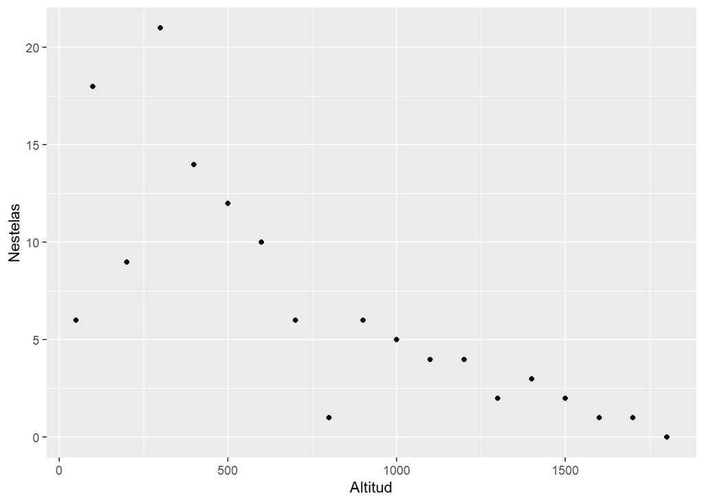

```r
ggplot(data = dat, aes(x=Altitud, y=Nestelas)) + geom_point()
```

## 3º) Comprobamos la distribucion del nº de estelas:

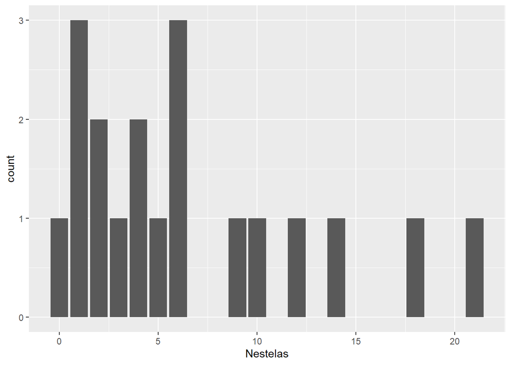

```r
ggplot(dat, aes(x=Nestelas)) + geom_bar()
```

```r
shapiro.test(dat$Nestelas)
```

```
##
##  Shapiro-Wilk normality test
##
## data:  dat$Nestelas
## W = 0.87693, p-value = 0.01899
```

# 4º) Generamos el modelo lineal para comprobar si la altitud predice el número de estelas:

```r
modelo <- lm(formula = Nestelas ~ Altitud,data = dat)
summary(modelo)
```

```
##
## Call:
## lm(formula = Nestelas ~ Altitud, data = dat)
##
## Residuals:
##     Min      1Q  Median      3Q     Max
## -7.7692 -1.0712  0.3019  1.0669  9.3391
##
## Coefficients:
##              Estimate Std. Error t value Pr(>|t|)
## (Intercept) 14.190814   1.703852   8.329 2.10e-07 ***
## Altitud     -0.008433   0.001617  -5.215 7.01e-05 ***
## ---
## Signif. codes:  0 '***' 0.001 '**' 0.01 '*' 0.05 '.' 0.1 ' ' 1
##
## Residual standard error: 3.831 on 17 degrees of freedom
## Multiple R-squared:  0.6153, Adjusted R-squared:  0.5927
## F-statistic: 27.19 on 1 and 17 DF,  p-value: 7.009e-05
```

```r
#Con un p-valor de 0.00007, podemos confirmar que sí existe una fuerte relación entre la altitud y el número de estelas

#Guardamos los coeficientes
coeficientes <- coef(modelo)
```

# Gráfico de dispersión

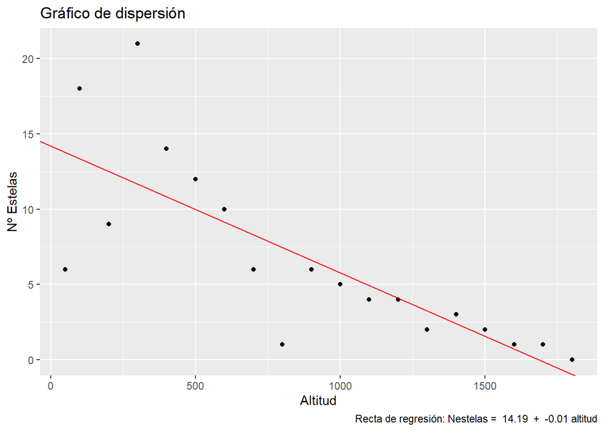

```r
ggplot(dat, aes(Altitud, Nestelas)) +
  geom_point() +                   # Agregar la nube de puntos
  geom_abline(intercept = coeficientes[1], slope = coeficientes[2], color = "red") + # Agregar la recta de regresión
  labs(title= "Gráfico de dispersión",caption = paste("Recta de regresión: Nestelas = ", round(coeficientes[1],2), " + ", round(coeficientes[2],2), "altitud"),
       x = "Altitud", y = "Nº Estelas") # Editar los nombres de los ejes
```

#medidas de influencia

```r
medidas_influencia <- influence.measures(lm(Nestelas ~ Altitud, dat))
medidas_influencia
```

```
## Influence measures of
##   lm(formula = Nestelas ~ Altitud, data = dat) :
##
##       dfb.1_  dfb.Altt    dffit cov.r   cook.d    hat inf
## 1  -1.223114  1.031730 -1.22351 0.685 5.60e-01 0.1822   *
## 2   0.610876 -0.506538  0.61174 1.088 1.78e-01 0.1674
## 3  -0.396055  0.315408 -0.39875 1.167 7.96e-02 0.1406
## 4   1.159311 -0.877001  1.18098 0.467 4.48e-01 0.1173   *
## 5   0.274255 -0.193893  0.28557 1.141 4.14e-02 0.0976
## 6   0.148745 -0.095780  0.16090 1.185 1.35e-02 0.0815
## 7   0.053922 -0.030241  0.06216 1.205 2.05e-03 0.0690
## 8  -0.119427  0.053310 -0.15260 1.148 1.21e-02 0.0599
## 9  -0.295593  0.082376 -0.44394 0.811 8.63e-02 0.0545
## 10 -0.019183  0.000179 -0.03689 1.188 7.22e-04 0.0526
## 11 -0.016890 -0.008351 -0.04735 1.188 1.19e-03 0.0543
## 12 -0.011587 -0.020553 -0.06021 1.192 1.92e-03 0.0596
## 13 -0.000209 -0.002431 -0.00506 1.212 1.36e-05 0.0684
## 14  0.008606 -0.056928 -0.09645 1.212 4.91e-03 0.0808
## 15 -0.010621  0.036248  0.05369 1.246 1.53e-03 0.0967
## 16 -0.012843  0.033153  0.04482 1.275 1.07e-03 0.1162
## 17 -0.011892  0.026155  0.03316 1.310 5.84e-04 0.1393
## 18 -0.059297  0.117399  0.14208 1.336 1.07e-02 0.1659
## 19 -0.064356  0.118242  0.13824 1.391 1.01e-02 0.1961   *
```

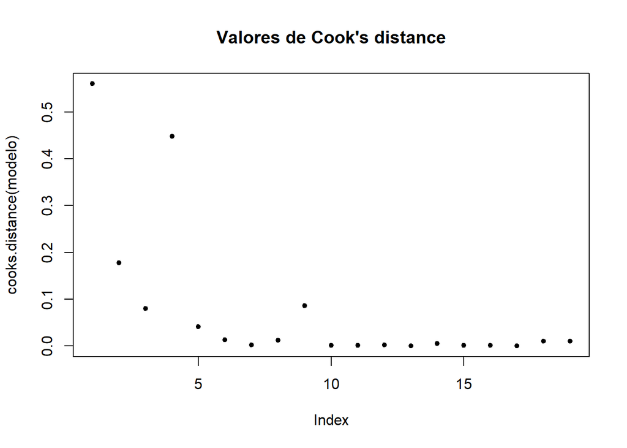

```r
plot(cooks.distance(modelo), pch = 20, main = "Valores de Cook's distance")
```

# supuesto de independencia de los residuos

```r
dwtest(modelo)
```

```
##
##  Durbin-Watson test
##
## data:  modelo
## DW = 1.98, p-value = 0.3778
## alternative hypothesis: true autocorrelation is greater than 0
```

# Confirme que los errores del modelo permanecen constantes para todo el rango de estimaciones.

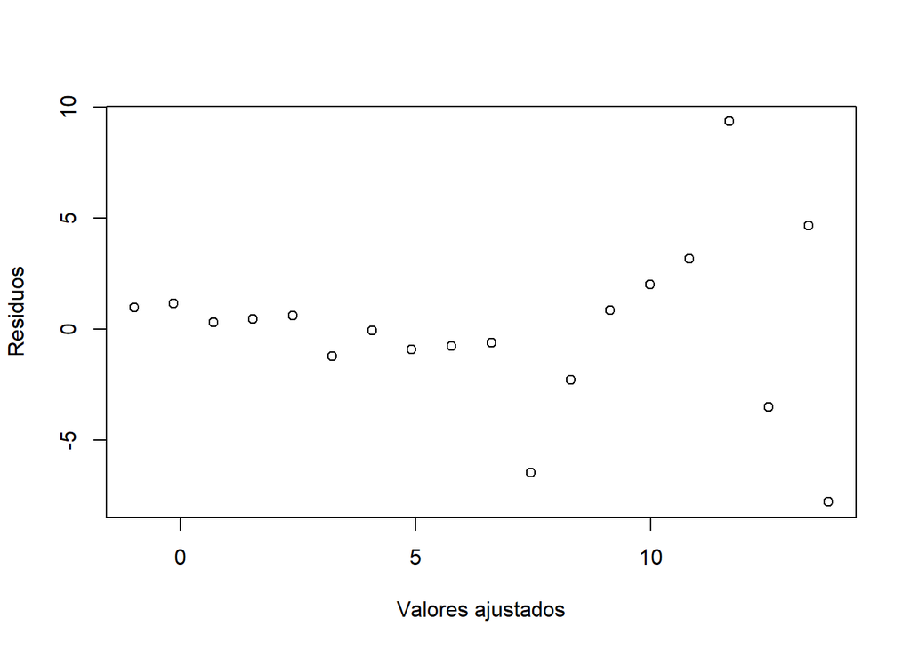

```r
plot(modelo$fitted.values, modelo$residuals, xlab = "Valores ajustados", ylab = "Residuos")
```